# Trabajo Final - Técnicas de Optimización con información imprecisa

Kelly Raas

5/7/2019

## Introducción

La Encuesta Mundial de Valores (EMV) o World Values Survey (WVS) es un proyecto global de investigación social que explora los valores y opiniones de la gente, cómo estos cambian con el tiempo, y su impacto social y político.

Entre otros valores la WVS mide el nivel de la “confianza en los demás” o “self-reported trust” que se construye como el número de personas que responden a la pregunta:

*“En términos generales, ¿diría que se puede confiar en la mayoría de las personas o que debe ser muy cuidadoso al tratar con las personas?”*

Las posibles respuestas incluyen “Se puede confiar en la mayoría de las personas”, “No sé” y “No se puede ser demasiado cuidadoso”. Las cifras representan el porcentaje que respondió “Se puede confiar en la mayoría de las personas” como parte de todas las respuestas. Los datos vienen para distintos años, sin embargo en este trabajo nos centraremos en analizar el resultado más reciente (2014) que contiene el nivel de confianza para 60 paises.

Sin duda al tratarse de datos que provienen de una encuesta y dado que “confianza” es un término qualitativo que no tiene medida exacta, se pueden considerar datos imprecisos.

EL objetivo del trabajo sera sacar algunas conclusiones interesantes de los datos y comparar si cambian los resultado aplicando numeros borrosos. Tratare de contestar a las siguientes preguntas:

- ¿Cuál es el país con menos confianza y cuál con más confianza?
- ¿Cuál es la mediana global de confianza?
- ¿Cómo comparan las medias de confianza por regiónes?
- ¿Cuál es la distribución global de confianza?

Para contestar estas preguntas usaré las differerntes técnicas de estadística descriptiva con numeros borrosos.

**Fuente de los datos:** Los datos utilizados en este trabajo provienen de https://ourworldindata.org/trust#trust-and-economic-outcomes. La fuente original es la World Values Survey (2014) (http://www.worldvaluessurvey.org/WVSDocumentationWVL.jsp)

## Preparación de los datos

Cargamos las librerias necesarias.

```r
library(tidyverse)
library(FuzzyNumbers)
```

Cargamos los datos.

```r
data = read.csv("self-reported-trust-attitudes.csv")
head(data)
```

```
     Entity Code Year Trust.in.others
1   Albania  ALB 1998        24.32432
2   Albania  ALB 2004        23.20000
3   Algeria  DZA 2004        10.76443
4   Algeria  DZA 2014        17.92863
5   Andorra  AND 2009        20.66199
6 Argentina  ARG 1984        26.09649
```

Seleccionamos los datos para el año 2014.

```r
data = data %>%
  filter(data$Year == 2014) %>%
  select(Entity, Trust.in.others)
head(data)
```

```
      Entity Trust.in.others
1    Algeria        17.92863
2  Argentina        22.64706
3    Armenia        10.01821
4  Australia        54.43383
5 Azerbaijan        16.16766
6    Bahrain        33.50000
```

Ahora que tenemos los datos que nos interesan preparados, procedemos a la fuzzificación de los mismos.

## Fuzzificación de los datos

Las preguntas de la encuesta de actitud proporcionan la principal fuente de datos para estimar las actitudes de confianza interpersonales, por lo que podemos suponer una cierta incertidumbre en los datos.

Sin embargo, la evidencia disponible para países con múltiples estimaciones de este tipo, sugiere que los resultados son bastante robustos. De hecho, al comparar las estimaciones entre países de diferentes encuestas que tratan de trazar los niveles de confianza interpersonales estimados según lo medido por la World Values Survey, contra los niveles de confianza interpersonales medidos por la European Social Survey y la Afrobarometer Survey obtienen una correlación positiva y muy alta (r = .92).

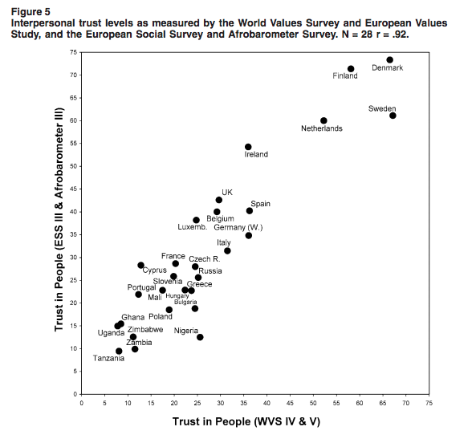

Teniendo esto en cuenta aplicaremos una incertidumbre de un 8% a los datos y como no hay indicaciones para suponer una asimetría usaremos números borrosos triangulares. Los datos ya están representados en porcentajes, por lo cual el soporte vendrá dado por [valor - 8 , valor + 8]. Además, como se trata de porcentajes los valores estarán cotados entre 0 y 100.

```r
# Función de fuzzificación
fuzzify = function(x, l, r){
  PiecewiseLinearFuzzyNumber(ifelse(x[1] - l < 0, 0, x[1] - l),
                             x[1],
                             x[1],
                             ifelse(x[1] + r > 100, 100, x[1] + r))}

# Fuzzificación de Trust.in.others
fuzzy_trust = apply(data[,"Trust.in.others",drop=F], 1, FUN = fuzzify, l = 8, r = 8)

# Adjuntar labels
names(fuzzy_trust) = data$Entity

# Mostrar un ejemplo
fuzzy_trust$Spain
```

```
Piecewise linear fuzzy number with 0 knot(s),
   support=[11.0194,27.0194],
      core=[19.0194,19.0194].
```

## ¿Cuál es el país con menos confianza y cuál con más confianza?

*Caso crisp:*

```r
# Mínimo
data$Entity[which(data$Trust.in.others %in% min(data$Trust.in.others))]
```

```
[1] Philippines
98 Levels: Albania Algeria Andorra Argentina Armenia ... Zimbabwe
```

```r
# Máximo
data$Entity[which(data$Trust.in.others %in% max(data$Trust.in.others))]
```

```
[1] Netherlands
98 Levels: Albania Algeria Andorra Argentina Armenia ... Zimbabwe
```

Según los datos crisp el País con menos “confianza en los demás” son las Filipinas el país con más “confianza en las demás” son los Paises Bajos.

*Caso borroso:*

```r
# Mínimo
trust_min = fuzzy_trust[[1]]
for (i in 2:length(fuzzy_trust)){
    trust_min = minimum(fuzzy_trust[[i]],trust_min)
  }
trust_min
```

```
Piecewise linear fuzzy number with 0 knot(s),
   support=[0,10.8333],
      core=[2.83333,2.83333].
```

```r
# Máximo
trust_max = fuzzy_trust[[1]]
for (i in 2:length(fuzzy_trust)){
    trust_max = maximum(fuzzy_trust[[i]],trust_max)
  }
trust_max
```

```
Piecewise linear fuzzy number with 0 knot(s),
   support=[58.1757,74.1757],
      core=[66.1757,66.1757].
```

Vamos a visualizar el minimo crisp y borroso junto con el maximo crisp y borroso.

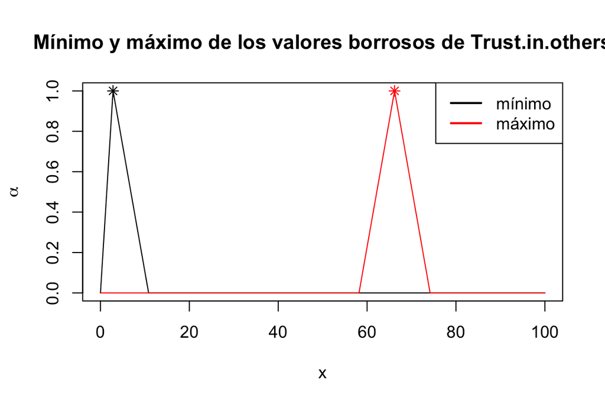

```r
plot(trust_min,xlim=c(0,100),col=1,main="Mínimo y máximo de los valores borrosos de Trust.in.others")
plot(trust_max,add=TRUE,col=2)
points(min(data$Trust.in.others), 1, col=1, pch=8)
points(max(data$Trust.in.others), 1, col=2, pch=8)
legend("topright",legend=c("mínimo","máximo"), lwd=c(2,2),col=1:2)
```

A continuación visualizaremos los 5 paises con más “confianza en los demás” y los 5 países con menos “confianza en los demás”.

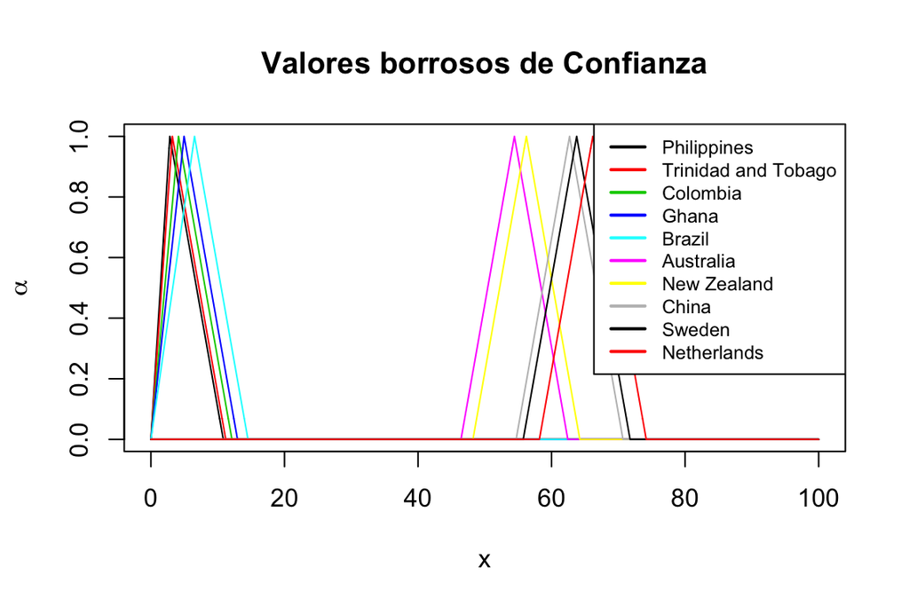

```r
fuzzy_trust_high = head(order(data$Trust.in.others),5)
fuzzy_trust_low = tail(order(data$Trust.in.others),5)

fuzzy_sample = c(fuzzy_trust_high, fuzzy_trust_low)

plot(fuzzy_trust[[fuzzy_sample[1]]], xlim=c(0,100),col=1,main="Valores borrosos de Confianza")
for (i in 2:10){
  plot(fuzzy_trust[[fuzzy_sample[i]]],col=i,add=TRUE)
}
legend("topright",legend=data$Entity[fuzzy_sample], lwd=c(2,2,2,2,2),col=1:10,cex=0.75)
```

Podemos observar que los países con más “confianza en los demás” son países en general más desarrollados mientras que los paises con menos “confianza en los demás” son países en general menos desarrollados. Dado el pronunciado gap entre los dos grupos podemos afirmar que la diferencia en el nivel de confianza además es considerable. Tambien vemos que en el caso borroso el máximo y mínimo corresponde a los mismos paises que en el caso crisp.

## ¿Cómo comparan las medias de confianza por regiónes?

Para poder comparar la “confianza en los demás” por regiones, primero tenemos que asignar el continente a cada país, ya que no viene dado en los datos originales y luego calcular la media crisp y la media borrosa para cada región.

```r
library(countrycode)

data$continent <- countrycode(sourcevar = data[, "Entity"],
                              origin = "country.name",
                              destination = "continent")

head(data)
```

```
      Entity Trust.in.others continent
1    Algeria        17.92863    Africa
2  Argentina        22.64706  Americas
3    Armenia        10.01821      Asia
4  Australia        54.43383   Oceania
5 Azerbaijan        16.16766      Asia
6    Bahrain        33.50000      Asia
```

*Caso crisp:*

```r
crisp_means = data %>%
  group_by(continent) %>%
  summarise(mean_trust = round(mean(Trust.in.others), 2))
crisp_means
```

```
# A tibble: 5 x 2
  continent mean_trust
  <chr>          <dbl>
1 Africa          14.4
2 Americas        13.0
3 Asia            25.3
4 Europe          33.0
5 Oceania         55.3
```

Según el caso crisp el nivel de “confianza en los demás” es más alto en Oceania y más bajo en Americas. Vamos a mirar el caso de Americas en más detalle.

```r
filter(data, continent == "Americas")
```

```
                Entity Trust.in.others continent
1            Argentina        22.64706  Americas
2               Brazil         6.52759  Americas
3                Chile        12.64016  Americas
4             Colombia         4.12783  Americas
5              Ecuador         7.16070  Americas
6               Mexico        12.40620  Americas
7                 Peru         8.21577  Americas
8  Trinidad and Tobago         3.20320  Americas
9        United States        38.17277  Americas
10             Uruguay        14.43515  Americas
```

Se puede observar claramente que aunque los EE.UU tiene un nivel de confianza mucho más alto que la media, la media se ve afectada sobre todo por los niveles de confianza muy bajos de los paises de Sudamérica. Sería interesante ver si un número borroso nos da un resultado que se ajuste mejor a la realidad.

*Caso borroso:*

Primero tenemos que agrupar los fuzzy numbers por continente.

```r
# obtener los índices
i_af = which(data$continent == "Africa")
i_am = which(data$continent == "Americas")
i_as = which(data$continent == "Asia")
i_eu = which(data$continent == "Europe")
i_oc = which(data$continent == "Oceania")

# agrupar fuzzy numbers por continente
AF = c()
for (i in 1:length(i_af)){
  AF = c(AF, fuzzy_trust[[i_af[i]]])
}
names(AF) = data$country[i_af]

AM = c()
for (i in 1:length(i_am)){
  AM = c(AM, fuzzy_trust[[i_am[i]]])
}
names(AM) = data$country[i_am]

AS = c()
for (i in 1:length(i_as)){
  AS = c(AS, fuzzy_trust[[i_as[i]]])
}
names(AS) = data$country[i_as]

EU = c()
for (i in 1:length(i_eu)){
  EU = c(EU, fuzzy_trust[[i_eu[i]]])
}
names(EU) = data$country[i_eu]

OC = c()
for (i in 1:length(i_oc)){
  OC = c(OC, fuzzy_trust[[i_oc[i]]])
}
names(OC) = data$country[i_oc]
```

Ahora podemos obtenemos la media borrosa por continente.

```r
# fución para obtener la media borrosa
fuzzy_mean = function(fnums){
  fuzzy_mean = fnums[[1]] * 1/length(fnums)
  for (i in 2:length(fnums)){
    fuzzy_mean = fuzzy_mean + fnums[[i]] * 1/length(fnums)
  }
  fuzzy_mean
}

# aplicamos la función
fuzzy_means = list(mean_AF = fuzzy_mean(AF),
                   mean_AM = fuzzy_mean(AM),
                   mean_AS = fuzzy_mean(AS),
                   mean_EU = fuzzy_mean(EU),
                   mean_OC = fuzzy_mean(OC))

# Mediana borrosa de Americas
fuzzy_means$mean_AM
```

```
Piecewise linear fuzzy number with 0 knot(s),
   support=[6.05171,20.9536],
      core=[12.9536,12.9536].
```

Evidentmenete la media borrosa para Americas con un soporte de [6.05 , 20.95] nos proporciona una mejor ajuste a lo que puede ser la realidad.

Vamos a visualizar la media del nivel de “confianza en los demás” para cada continente.

[figure not shown]

```r
plot(fuzzy_means[[1]], xlim=c(0,100), col=1, main="Confianza media por continente")
points(crisp_means$mean_trust[1], 1, col=1, pch = 8)
for (i in 2:length(fuzzy_means)){
  plot(fuzzy_means[[i]], col=i, add=TRUE)
  points(crisp_means$mean_trust[i], 1, col=i, pch = 8)
}
legend("topright", legend=unique(data$continent), lwd=rep(2,5),col=1:5,cex=0.75)
```

## ¿Cuál es la mediana global de confianza?

Para poder calcular la mediana borrosa tenemos que implementar una función que nos calcula el p-cuantil borroso de una colección de números borrosos.

*Caso crisp:*

```r
median(data$Trust.in.others)
```

```
[1] 20.26639
```

*Caso borroso:*

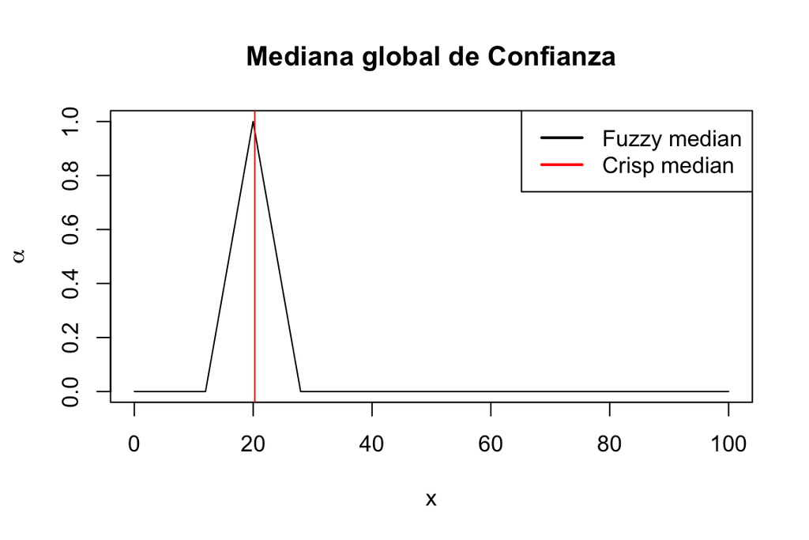

```r
# Función para calcular un quantil borroso
cuantil_borroso=function (x,p,cuts){
  izq=c()
  der=c()
  for (i in seq(0,1,1/cuts)){
    df=data.frame(izq=c(),der=c())
    for (j in 1:length(x)){
      corte=alphacut(x[[j]],i)
      df=rbind(df,data.frame(izq=corte[1],der=corte[2]))
    }
    dfizq=df[order(df$izq),]
    dfder=df[order(df$der),]
    izq=c(izq,dfizq[floor(p*length(x)),]$izq)
    der=c(der,dfder[floor(p*length(x)),]$der)
  }
  cuantil_borroso=PiecewiseLinearFuzzyNumber(izq[1],izq[length(izq)],der[length(der)],der[1],knot.alpha=seq(0,1,1/cuts),knot.left=izq,knot.right=sort(der,decreasing=FALSE))
}

# Mediana borrosa de Trust.in.others
fuzzy_median_trust = cuantil_borroso(fuzzy_trust, 0.5, 10)

# Visualización
plot(piecewiseLinearApproximation(fuzzy_median_trust),xlim=c(0,100), main="Mediana global de Confianza")
abline(v = median(data$Trust.in.others), col = 2)
legend("topright",legend=c("Fuzzy median","Crisp median"),lwd=c(2,2),
col=c(1,2))
```

*Caso crisp:*

```r
crisp_distance = data.frame(entity=c(),distance=c())
med = median(data$Trust.in.others)
for (i in length(data$Entity)){
  crisp_distance = rbind(crisp_distance, data.frame(entity = data[i,"Entity"],
                                                    distance = abs(med - data[i,"Trust.in.others"])))
}
crisp_distance[order(crisp_distance$distance)[1],]
```

```
    entity distance
1 Zimbabwe 13.06639
```

*Caso borroso:*

```r
fuzzy_distance = data.frame(entity=c(), distance=c())
for (i in length(data$Entity)){
  fuzzy_distance=rbind(fuzzy_distance, data.frame(entity=data[i,"Entity"],
                                                  distance = distance(fuzzy_median_trust,fuzzy_trust[[i]])))
}
fuzzy_distance[order(fuzzy_distance$distance)[1],]
```

```
    entity distance
1 Zimbabwe 17.79631
```

# ¿Cuál es la distribución global de confianza?

Por último queremos analizar cómo se distribuye el nivel de “confianza en lod demás”" a nivel global. Para ello comparamos la distribución de un nivel de confianza menor que 50% y mayor de un 50%, es decir comparamos las frequencias relativas crisp y borrosas para las clases [0,49] y [50,10].

*Caso Crisp:*

```r
data %>%
  select("Entity","Trust.in.others") %>%
  mutate(class = ifelse(Trust.in.others >= 50, "Confianza alta", "Confianza baja")) %>%
  group_by(class) %>%
  summarise(count = n_distinct(Entity),
            rel_freq = round(count/60, 2))
```

```
# A tibble: 2 x 3
  class          count rel_freq
  <chr>          <int>    <dbl>
1 Confianza alta     5     0.08
2 Confianza baja    55     0.92
```

Según este resultado crisp podemos decir que tan solo un 8% de los paises tienen un nivel de confianza alta mientras que el 92% tiene un nivel de confianza baja. Comparemoslo con el caso borroso.

*Caso borroso:*

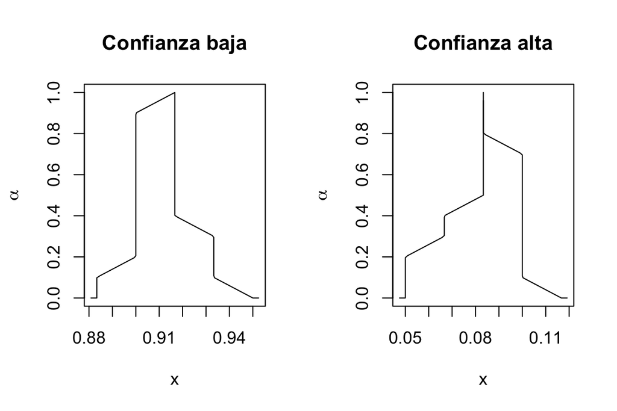

```r
# función para calcular la frecuencia relativa borrosa
interseccion=function(x,a,b){
  if (x[2]<a | x[1]>b){interseccion=0}
  else {interseccion=1}
}
contenido=function(x,a,b){
  if (x[1]>=a & x[2]<=b){contenido=1}
  else {contenido=0}
}
frec_rel_borrosa=function (x,a,b,cuts){
  izq=c()
  der=c()
  for (i in seq(0,1,1/cuts)){
    df=data.frame(izq=c(),der=c())
    for (j in 1:length(x)){
      corte=alphacut(x[[j]],i)
      df=rbind(df,data.frame(izq=corte[1],der=corte[2]))
    }
    intersec=apply(df,1,FUN=interseccion,a=a,b=b)
    sub=apply(df,1,FUN=contenido,a=a,b=b)
    izq=c(izq,sum(sub)/length(x))
    der=c(der,sum(intersec)/length(x))
  }
  frec_rel_borrosa=PiecewiseLinearFuzzyNumber(izq[1],izq[length(izq)],der[length(der)],der[1],knot.alpha=seq(0,1,1/cuts),knot.left=izq,knot.right=sort(der,decreasing=FALSE))
}

par(mfrow = c(1,2))
plot(frec_rel_borrosa(fuzzy_trust,0,49,10), main="Confianza baja")
plot(frec_rel_borrosa(fuzzy_trust,50,100,10), main="Confianza alta")
```

Mientras el caso crisp solo un 8% de los paises tenían una confianza alta, en el caso borroso podemos decir que dependiendo del delta-corte entre el 5% y 12% de los paises tienen una confianza alta. Igual con el caso de confianza baja, que según el caso borroso son el 88% a 95% de los paises.